# ICD - Grupo 5: American Time Use Survey (ATUS) 2025 - Check-in #2

Análise exploratória, estatísticas descritivas e visualização de dados

2026-10-29

# 1. Preparação e qualidade dos dados

## 1.1 Importação

A base principal é construída a partir de três arquivos brutos do ATUS 2025, todos em formato CSV (apesar da extensão `.dat`), ligados pela chave `TUCASEID`:

- **Activity Summary** (`atussum_2025.dat`): 1 linha por respondente, com minutos totais em cada atividade e a maioria das variáveis demográficas/laborais já usadas no Check-in #1.
- **Respondent** (`atusresp_2025.dat`): 1 linha por respondente; usado aqui só para trazer `TRMJOCGR` (grupo de ocupação), que não está no Activity Summary.
- **Activity** (`atusact_2025.dat`): várias linhas por respondente (uma por atividade), usado para reconstruir onde cada respondente trabalhou (`TEWHERE`) e assim derivar a variável “trabalhou em casa”.

```r
resp <- read_csv(file.path(base_dir, "atusresp-2025/atusresp_2025.dat"),
                  col_types = cols(.default = "d", TUCASEID = "c"))

sumfile <- read_csv(file.path(base_dir, "atussum-2025/atussum_2025.dat"),
                     col_types = cols(.default = "d", TUCASEID = "c"))

act <- read_csv(file.path(base_dir, "atusact-2025/atusact_2025.dat"),
                 col_types = cols(.default = "d", TUCASEID = "c"))

cat("Linhas em atussum (1 por respondente):", nrow(sumfile), "\n")
```

```
## Linhas em atussum (1 por respondente): 6146
```

```r
cat("Linhas em atusresp (1 por respondente):", nrow(resp), "\n")
```

```
## Linhas em atusresp (1 por respondente): 6146
```

```r
cat("Linhas em atusact (1 por atividade):", nrow(act), "\n")
```

```
## Linhas em atusact (1 por atividade): 114151
```

```r
cat("Duplicatas de TUCASEID em atussum:", sum(duplicated(sumfile$TUCASEID)), "\n")
```

```
## Duplicatas de TUCASEID em atussum: 0
```

Não há duplicatas de `TUCASEID` nos arquivos de 1 linha por respondente, como esperado pelo desenho da pesquisa.

## 1.2 Variáveis derivadas

**Minutos de lazer e esportes.** Somamos todas as colunas de atividade que começam com `t12` (socializar, relaxar e lazer) ou `t13` (esportes, exercício e recreação) no Activity Summary.

```r
leisure_cols <- grep("^t1[23]\\d{4}$", names(sumfile), value = TRUE)
length(leisure_cols)
```

```
## [1] 77
```

```r
sumfile <- sumfile %>%
  mutate(lazer_min = rowSums(across(all_of(leisure_cols)), na.rm = TRUE))

summary(sumfile$lazer_min)
```

```
##    Min. 1st Qu.  Median    Mean 3rd Qu.    Max.
##     0.0   160.0   300.0   333.1   480.0  1290.0
```

**Trabalhou em casa.** No arquivo de atividades, filtramos as atividades de trabalho (`TUTIER1CODE == 5 & TUTIER2CODE == 1`, isto é, código de 6 dígitos 0501xx = “Working”) e verificamos se, para algum registro dessas atividades, o local (`TEWHERE`) foi 1 (“Respondent’s home or yard”). `TEWHERE` não é coletado para algumas atividades e usa -1 nesses casos; tratamos -1 como “não informado”, não como “não trabalhou em casa”.

```r
work_home_flag <- act %>%
  filter(TUTIER1CODE == 5, TUTIER2CODE == 1) %>%
  group_by(TUCASEID) %>%
  summarise(
    minutos_trabalho = sum(TUACTDUR, na.rm = TRUE),
    trabalhou_em_casa = as.integer(any(TEWHERE == 1)),
    .groups = "drop"
  )

nrow(work_home_flag)
```

```
## [1] 1894
```

## 1.3 Junção das bases

```r
base <- sumfile %>%
  left_join(resp %>% select(TUCASEID, TRMJOCGR), by = "TUCASEID") %>%
  left_join(work_home_flag %>% select(TUCASEID, trabalhou_em_casa, minutos_trabalho),
            by = "TUCASEID")

nrow(base)
```

```
## [1] 6146
```

Respondentes sem nenhuma atividade de trabalho no `atusact` (não empregados, ou empregados que não trabalharam no dia do diário) ficam com `trabalhou_em_casa = NA`. Isso é esperado e será tratado como um subconjunto diferente (população = empregados que trabalharam no dia do diário), não como dado ausente a ser imputado.

## 1.4 Tratamento de códigos de ausente / não aplicável

Seguindo o dicionário de dados (ATUS usa -1 = blank/não aplicável, -2 = don’t know, -3 = refused, e -4 = “horas variam” em algumas variáveis de horas):

```r
base <- base %>%
  mutate(
    # TRDPFTPT: -1 marca quem não está empregado -> não é faltante, é categoria própria
    TRDPFTPT_lab = case_when(
      TRDPFTPT == 1 ~ "Integral",
      TRDPFTPT == 2 ~ "Parcial",
      TRDPFTPT == -1 ~ "Não empregado",
      TRUE ~ NA_character_
    ),
    # TEHRUSLT: -4 = horas variam, -1 = não aplica -> tratados como categorias, não removidos
    TEHRUSLT_clean = ifelse(TEHRUSLT %in% c(-1, -4), NA_real_, TEHRUSLT),
    horas_variam = TEHRUSLT == -4,
    # TRERNWA: só definido para empregados assalariados; -1 = não aplicável
    TRERNWA_clean = ifelse(TRERNWA == -1, NA_real_, TRERNWA / 100),  # 2 casas decimais implícitas -> US$
    # TRMJOCGR: -1 = não aplica (não empregado)
    TRMJOCGR_lab = case_when(
      TRMJOCGR == 1 ~ "Gerência/profissional",
      TRMJOCGR == 2 ~ "Serviços",
      TRMJOCGR == 3 ~ "Vendas/escritório",
      TRMJOCGR == 4 ~ "Agropecuária/pesca/silvicultura",
      TRMJOCGR == 5 ~ "Construção/manutenção",
      TRMJOCGR == 6 ~ "Produção/transporte",
      TRUE ~ NA_character_
    ),
    TESEX_lab = ifelse(TESEX == 1, "Masculino", "Feminino"),
    TUDIARYDAY_lab = factor(TUDIARYDAY,
      levels = 1:7,
      labels = c("Domingo", "Segunda", "Terça", "Quarta", "Quinta", "Sexta", "Sábado")
    ),
    fim_de_semana = TUDIARYDAY %in% c(1, 7),
    TELFS_lab = case_when(
      TELFS == 1 ~ "Empregado trabalhando",
      TELFS == 2 ~ "Empregado afastado",
      TELFS == 3 ~ "Desempregado (layoff)",
      TELFS == 4 ~ "Desempregado (procurando)",
      TELFS == 5 ~ "Fora da força de trabalho",
      TRUE ~ NA_character_
    ),
    trabalhou_em_casa_lab = case_when(
      trabalhou_em_casa == 1 ~ "Sim",
      trabalhou_em_casa == 0 ~ "Não",
      TRUE ~ NA_character_
    ),
    # PEEDUCA: agrupamento em faixas (códigos no dicionário CPS 31-46)
    escolaridade = case_when(
      PEEDUCA <= 38 ~ "Menos que ensino médio",
      PEEDUCA == 39 ~ "Ensino médio completo",
      PEEDUCA %in% c(40, 41, 42) ~ "Superior incompleto/técnico",
      PEEDUCA == 43 ~ "Bacharelado",
      PEEDUCA %in% c(44, 45, 46) ~ "Pós-graduação",
      TRUE ~ NA_character_
    ),
    escolaridade = factor(escolaridade, levels = c(
      "Menos que ensino médio", "Ensino médio completo",
      "Superior incompleto/técnico", "Bacharelado", "Pós-graduação"
    )),
    TEAGE_clean = ifelse(TEAGE < 0, NA_real_, TEAGE)
  )
```

**Decisões de tratamento (resumo):**

- Códigos −1/−2/−3/−4 nunca foram tratados como “zero”: viraram `NA` quando representam dado realmente ausente para a análise em questão, ou uma categoria própria (“Não empregado”, “horas variam”) quando descrevem uma condição válida do respondente.
- `TRERNWA` (rendimento semanal) só é interpretável para empregados assalariados (TELFS 1-2 e tipo de vínculo 1-5); por isso análises com essa variável usam explicitamente o subconjunto de quem tem valor não-ausente.
- Não removemos nenhuma observação da base principal (6.146 respondentes): os “ausentes” ficam como `NA` e cada tabela/gráfico declara a população que está de fato usando.
- Peso amostral `TUFINLWGT` foi mantido e usado nas estatísticas descritivas ponderadas (médias, medianas, proporções), já que a ATUS sobreamostra fins de semana e tem desenho amostral complexo.
- Nenhuma duplicata encontrada; nenhuma unidade de medida precisou de conversão além de minutos (já padronizados pelo próprio arquivo) e centavos -> dólares em `TRERNWA`.

# 2. Dimensão da base após a preparação

```r
cat("Observações (respondentes) na base principal:", nrow(base), "\n")
```

```
## Observações (respondentes) na base principal: 6146
```

```r
cat("Variáveis selecionadas para a análise:",
    length(c("lazer_min","trabalhou_em_casa","TUDIARYDAY","TRCHILDNUM","TRMJOCGR",
              "TEAGE","TESEX","escolaridade","TELFS","TRERNWA")), "\n")
```

```
## Variáveis selecionadas para a análise: 10
```

```r
cat("\nSubconjuntos usados por análise:\n")
```

```
##
## Subconjuntos usados por análise:
```

```r
cat("- Todos os respondentes (lazer, dia da semana, filhos):", nrow(base), "\n")
```

```
## - Todos os respondentes (lazer, dia da semana, filhos): 6146
```

```r
cat("- Com atividade de trabalho registrada no diário (trabalhou_em_casa não-NA):",
    sum(!is.na(base$trabalhou_em_casa)), "\n")
```

```
## - Com atividade de trabalho registrada no diário (trabalhou_em_casa não-NA): 1894
```

```r
cat("- Empregados assalariados com TRERNWA válido:",
    sum(!is.na(base$TRERNWA_clean)), "\n")
```

```
## - Empregados assalariados com TRERNWA válido: 3037
```

```r
cat("- Com TRMJOCGR definido (empregados):", sum(!is.na(base$TRMJOCGR_lab)), "\n")
```

```
## - Com TRMJOCGR definido (empregados): 3411
```

Nenhuma observação foi excluída da base de 6.146 respondentes; o que varia de análise para análise é quantas observações têm valor válido (não-`NA`) na(s) variável(is) envolvida(s), e isso é reportado em cada tabela/gráfico abaixo.

# 3. Análise descritiva das principais variáveis

10 variáveis selecionadas, incluindo as 5 obrigatórias do Check-in #1 (`lazer_min`, `trabalhou_em_casa`, `TUDIARYDAY`, `TRCHILDNUM`, `TRMJOCGR`) + `TEAGE`, `TESEX`, `escolaridade` (PEEDUCA agrupado), `TELFS`, `TRERNWA`.

## 3.1 Variáveis numéricas

```r
num_vars <- list(
  "Minutos de lazer/esportes (lazer_min)" = base$lazer_min,
  "Idade (TEAGE)" = base$TEAGE_clean,
  "Número de crianças no domicílio (TRCHILDNUM)" = base$TRCHILDNUM,
  "Rendimento semanal, US$ (TRERNWA, só assalariados)" = base$TRERNWA_clean
)

desc_num <- map_dfr(names(num_vars), function(nm) {
  x <- num_vars[[nm]]
  w <- base$TUFINLWGT
  tibble(
    variavel = nm,
    n_validos = sum(!is.na(x)),
    n_ausentes = sum(is.na(x)),
    media_pond = wtd_mean(x, w),
    mediana_pond = wtd_quantile(x, w, 0.5),
    q1_pond = wtd_quantile(x, w, 0.25),
    q3_pond = wtd_quantile(x, w, 0.75),
    minimo = min(x, na.rm = TRUE),
    maximo = max(x, na.rm = TRUE)
  )
})

desc_num %>% mutate(across(where(is.numeric), ~round(., 1)))
```

| variavel | n_validos | n_ausentes | media_pond | mediana_pond | q1_pond | q3_pond | minimo | maximo |
| --- | --- | --- | --- | --- | --- | --- | --- | --- |
| Minutos de lazer/esportes (lazer_min) | 6146 | 0 | 298.4 | 259 | 135 | 432 | 0 | 1290.0 |
| Idade (TEAGE) | 6146 | 0 | 46.7 | 45 | 30 | 63 | 15 | 85.0 |
| Número de crianças no domicílio (TRCHILDNUM) | 6146 | 0 | 0.7 | 0 | 0 | 1 | 0 | 8.0 |
| Rendimento semanal, US$ (TRERNWA, só assalariados) | 3037 | 3109 | 1571.0 | 1096 | 680 | 1840 | 0 | 13258.2 |

## 3.2 Variáveis categóricas

```r
cat_summary <- function(data, var, label) {
  data %>%
    filter(!is.na(.data[[var]])) %>%
    count(.data[[var]], wt = TUFINLWGT, name = "peso") %>%
    mutate(proporcao = peso / sum(peso),
           variavel = label) %>%
    rename(categoria = 1) %>%
    arrange(desc(proporcao))
}

bind_rows(
  cat_summary(base, "TESEX_lab", "Sexo"),
  cat_summary(base, "TUDIARYDAY_lab", "Dia da semana do diário"),
  cat_summary(base, "escolaridade", "Escolaridade (agrupada)"),
  cat_summary(base, "TELFS_lab", "Situação na força de trabalho"),
  cat_summary(base, "TRMJOCGR_lab", "Grupo de ocupação (só empregados)"),
  cat_summary(base, "trabalhou_em_casa_lab", "Trabalhou em casa no dia (só c/ atividade de trabalho)")
) %>%
  select(variavel, categoria, peso, proporcao) %>%
  mutate(proporcao = percent(proporcao, accuracy = 0.1))
```

| variavel | categoria | peso | proporcao |
| --- | --- | --- | --- |
| Sexo | Feminino | 51953868576 | 51.2% |
| Sexo | Masculino | 49510531406 | 48.8% |
| Dia da semana do diário | Terça | 15257116377 | 15.0% |
| Dia da semana do diário | Segunda | 14593185195 | 14.4% |
| Dia da semana do diário | Sábado | 14474913771 | 14.3% |
| Dia da semana do diário | Domingo | 14434920184 | 14.2% |
| Dia da semana do diário | Quarta | 14378459443 | 14.2% |
| Dia da semana do diário | Sexta | 14266027617 | 14.1% |
| Dia da semana do diário | Quinta | 14059777395 | 13.9% |
| Escolaridade (agrupada) | Ensino médio completo | 27754777713 | 27.4% |

[output cut: 17 more lines]

Categorias raras: dentro de `TRMJOCGR`, “Agropecuária/pesca/silvicultura” é a menos frequente (poucas dezenas de casos na amostra, bem abaixo de 5% dos empregados); isso já era esperado pelo Check-in #1 e deve ser lembrado ao interpretar análises cruzadas com essa categoria.

# 4. Visualização das distribuições

## 4.1 Minutos de lazer (histograma)

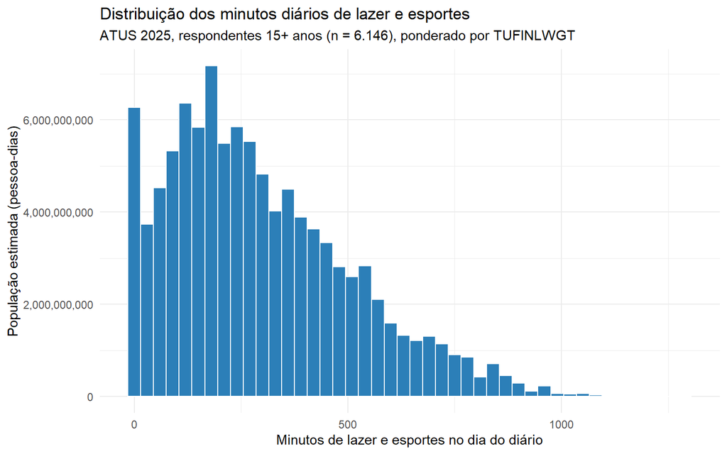

```r
ggplot(base, aes(x = lazer_min, weight = TUFINLWGT)) +
  geom_histogram(binwidth = 30, fill = "#2c7fb8", color = "white") +
  scale_y_continuous(labels = label_comma()) +
  labs(
    title = "Distribuição dos minutos diários de lazer e esportes",
    subtitle = "ATUS 2025, respondentes 15+ anos (n = 6.146), ponderado por TUFINLWGT",
    x = "Minutos de lazer e esportes no dia do diário",
    y = "População estimada (pessoa-dias)"
  ) +
  theme_minimal()
```

## 4.2 Idade (densidade)

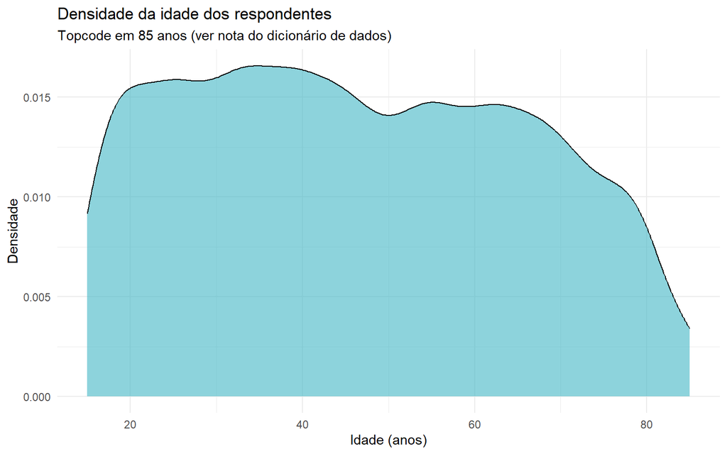

```r
ggplot(base, aes(x = TEAGE_clean, weight = TUFINLWGT)) +
  geom_density(fill = "#41b6c4", alpha = 0.6) +
  labs(
    title = "Densidade da idade dos respondentes",
    subtitle = "Topcode em 85 anos (ver nota do dicionário de dados)",
    x = "Idade (anos)",
    y = "Densidade"
  ) +
  theme_minimal()
```

## 4.3 Escolaridade (barras)

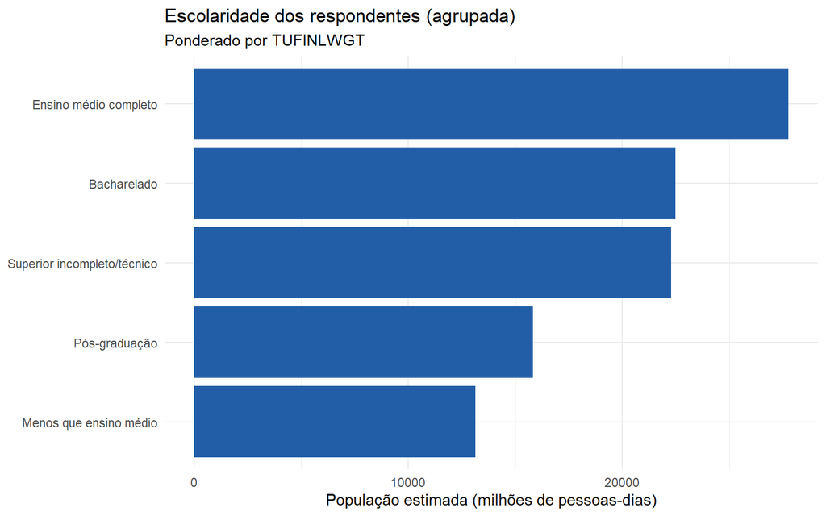

```r
base %>%
  filter(!is.na(escolaridade)) %>%
  count(escolaridade, wt = TUFINLWGT) %>%
  ggplot(aes(x = fct_reorder(escolaridade, n), y = n / 1e6)) +
  geom_col(fill = "#225ea8") +
  coord_flip() +
  labs(
    title = "Escolaridade dos respondentes (agrupada)",
    subtitle = "Ponderado por TUFINLWGT",
    x = NULL,
    y = "População estimada (milhões de pessoas-dias)"
  ) +
  theme_minimal()
```

## 4.4 Minutos de lazer por situação de trabalho em casa (boxplot)

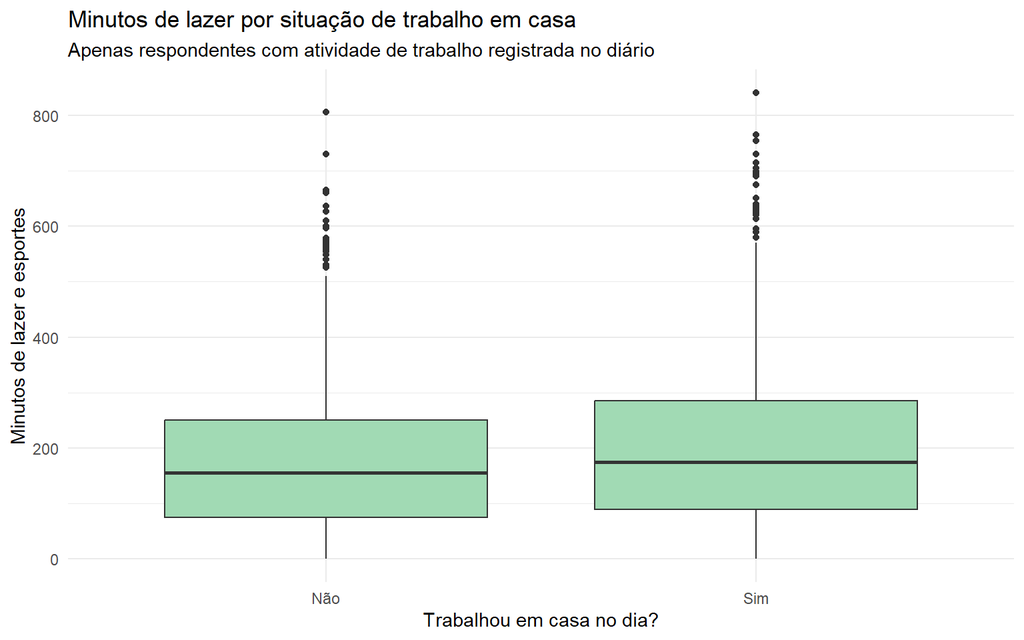

```r
base %>%
  filter(!is.na(trabalhou_em_casa_lab)) %>%
  ggplot(aes(x = trabalhou_em_casa_lab, y = lazer_min)) +
  geom_boxplot(fill = "#a1dab4") +
  labs(
    title = "Minutos de lazer por situação de trabalho em casa",
    subtitle = "Apenas respondentes com atividade de trabalho registrada no diário",
    x = "Trabalhou em casa no dia?",
    y = "Minutos de lazer e esportes"
  ) +
  theme_minimal()
```

## 4.5 ECDF do rendimento semanal (só assalariados)

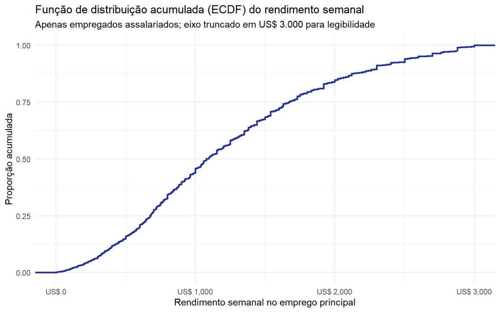

```r
base %>%
  filter(!is.na(TRERNWA_clean)) %>%
  ggplot(aes(x = TRERNWA_clean)) +
  stat_ecdf(color = "#253494", linewidth = 1) +
  scale_x_continuous(labels = label_dollar(prefix = "US$ "), limits = c(0, 3000)) +
  labs(
    title = "Função de distribuição acumulada (ECDF) do rendimento semanal",
    subtitle = "Apenas empregados assalariados; eixo truncado em US$ 3.000 para legibilidade",
    x = "Rendimento semanal no emprego principal",
    y = "Proporção acumulada"
  ) +
  theme_minimal()
```

A ECDF mostra que a mediana de rendimento semanal fica perto de US$ 1.000–1.200, e que cerca de 90% dos assalariados ganham menos de US$ 2.500/semana, confirmando a assimetria à direita já identificada na tabela da seção 3.1.

# 5. Relações entre variáveis

## 5.1 Numérica × Numérica: idade vs. minutos de lazer

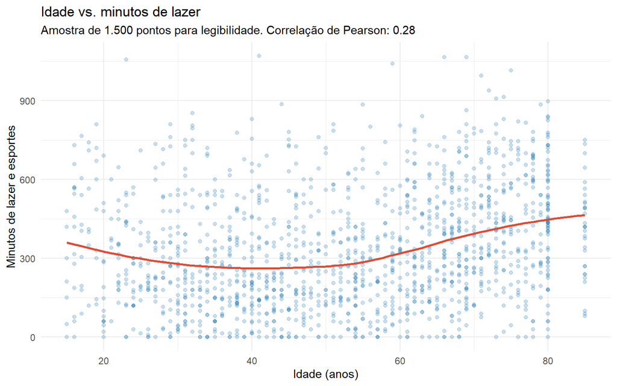

```r
cor_val <- cor(base$TEAGE_clean, base$lazer_min, use = "complete.obs")

base %>%
  slice_sample(n = 1500) %>%
  ggplot(aes(x = TEAGE_clean, y = lazer_min)) +
  geom_point(alpha = 0.25, color = "#2c7fb8") +
  geom_smooth(method = "loess", color = "#e34a33", se = FALSE) +
  labs(
    title = "Idade vs. minutos de lazer",
    subtitle = paste0("Amostra de 1.500 pontos para legibilidade. Correlação de Pearson: ", round(cor_val, 2)),
    x = "Idade (anos)",
    y = "Minutos de lazer e esportes"
  ) +
  theme_minimal()
```

Correlação fraca e positiva: respondentes mais velhos tendem a ter um pouco mais de tempo de lazer, provavelmente refletindo menor participação na força de trabalho entre os mais idosos.

## 5.2 Numérica × Categórica: lazer por dia da semana

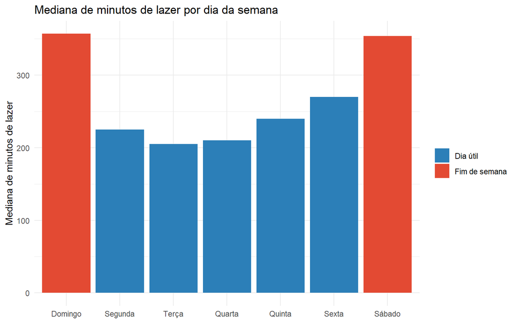

```r
base %>%
  group_by(TUDIARYDAY_lab, fim_de_semana) %>%
  summarise(lazer_mediano = wtd_quantile(lazer_min, TUFINLWGT, 0.5), .groups = "drop") %>%
  ggplot(aes(x = TUDIARYDAY_lab, y = lazer_mediano, fill = fim_de_semana)) +
  geom_col() +
  scale_fill_manual(values = c("TRUE" = "#e34a33", "FALSE" = "#2c7fb8"),
                     labels = c("Dia útil", "Fim de semana"), name = NULL) +
  labs(
    title = "Mediana de minutos de lazer por dia da semana",
    x = NULL, y = "Mediana de minutos de lazer"
  ) +
  theme_minimal()
```

Fins de semana (sobreamostrados no desenho da ATUS) têm mediana de lazer visivelmente maior que dias úteis, confirmando a hipótese do Check-in #1 de que `TUDIARYDAY` é um preditor relevante do tempo de lazer.

## 5.3 Numérica × Categórica: rendimento semanal por grupo de ocupação

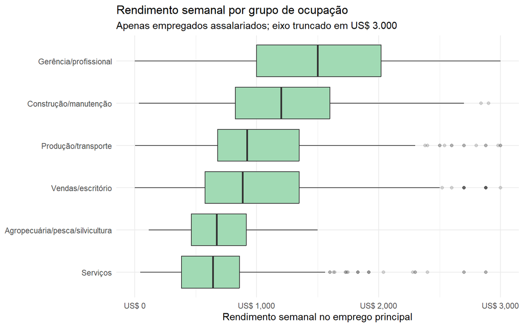

```r
base %>%
  filter(!is.na(TRMJOCGR_lab), !is.na(TRERNWA_clean)) %>%
  ggplot(aes(x = fct_reorder(TRMJOCGR_lab, TRERNWA_clean, median), y = TRERNWA_clean)) +
  geom_boxplot(fill = "#a1dab4", outlier.alpha = 0.2) +
  coord_flip() +
  scale_y_continuous(labels = label_dollar(prefix = "US$ "), limits = c(0, 3000)) +
  labs(
    title = "Rendimento semanal por grupo de ocupação",
    subtitle = "Apenas empregados assalariados; eixo truncado em US$ 3.000",
    x = NULL, y = "Rendimento semanal no emprego principal"
  ) +
  theme_minimal()
```

## 5.4 Categórica × Categórica: trabalhou em casa × grupo de ocupação

```r
tab_wfh_occ <- base %>%
  filter(!is.na(trabalhou_em_casa_lab), !is.na(TRMJOCGR_lab)) %>%
  count(TRMJOCGR_lab, trabalhou_em_casa_lab, wt = TUFINLWGT) %>%
  group_by(TRMJOCGR_lab) %>%
  mutate(proporcao = n / sum(n)) %>%
  ungroup()

tab_wfh_occ %>%
  select(TRMJOCGR_lab, trabalhou_em_casa_lab, proporcao) %>%
  pivot_wider(names_from = trabalhou_em_casa_lab, values_from = proporcao) %>%
  mutate(across(where(is.numeric), ~percent(., accuracy = 0.1)))
```

| TRMJOCGR_lab | Não | Sim |
| --- | --- | --- |
| Agropecuária/pesca/silvicultura | 79.9% | 20.1% |
| Construção/manutenção | 85.6% | 14.4% |
| Gerência/profissional | 49.3% | 50.7% |
| Produção/transporte | 91.1% | 8.9% |
| Serviços | 86.6% | 13.4% |
| Vendas/escritório | 68.0% | 32.0% |

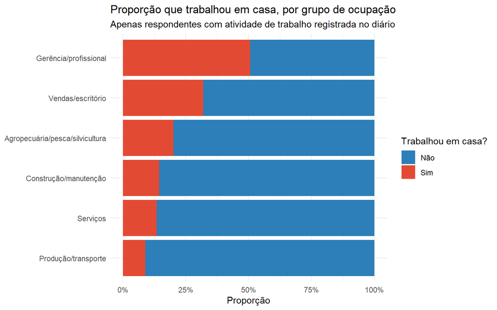

```r
ggplot(tab_wfh_occ, aes(x = fct_reorder(TRMJOCGR_lab, proporcao * (trabalhou_em_casa_lab == "Sim")),
                         y = proporcao, fill = trabalhou_em_casa_lab)) +
  geom_col(position = "fill") +
  coord_flip() +
  scale_y_continuous(labels = percent) +
  scale_fill_manual(values = c("Sim" = "#e34a33", "Não" = "#2c7fb8"), name = "Trabalhou em casa?") +
  labs(
    title = "Proporção que trabalhou em casa, por grupo de ocupação",
    subtitle = "Apenas respondentes com atividade de trabalho registrada no diário",
    x = NULL, y = "Proporção"
  ) +
  theme_minimal()
```

## 5.5 Categórica × Categórica: número de filhos × trabalhou em casa

```r
base %>%
  filter(!is.na(trabalhou_em_casa_lab)) %>%
  mutate(tem_filhos = ifelse(TRCHILDNUM > 0, "Tem filhos < 18", "Sem filhos < 18")) %>%
  count(tem_filhos, trabalhou_em_casa_lab, wt = TUFINLWGT) %>%
  group_by(tem_filhos) %>%
  mutate(proporcao = n / sum(n)) %>%
  ungroup() %>%
  select(tem_filhos, trabalhou_em_casa_lab, proporcao) %>%
  pivot_wider(names_from = trabalhou_em_casa_lab, values_from = proporcao) %>%
  mutate(across(where(is.numeric), ~percent(., accuracy = 0.1)))
```

| tem_filhos | Não | Sim |
| --- | --- | --- |
| Sem filhos < 18 | 65.9% | 34.1% |
| Tem filhos < 18 | 64.3% | 35.7% |